# RestoreDART results, organized by finding

BEM

October 2026

## Notes

- This document reports the same analysis as `2_make_DART_results.Rmd` organized a different way. That document is ordered by the quantity computed - overall significance, then per-polygon, then timing, then overlap - which is the order the tables were built in. This one is ordered by the four findings those quantities support, in the order KY proposed in `analysis_modification_suggestions_08102026`: whether treatments worked, which treatments worked, how long the effects lasted, and what else changed. It is the document the manuscript Results are written from.
- Nothing here is a new analysis. Every number below is read off the same compiled tables the other documents display, and the four figures are new views of those tables rather than new estimates. Where this document departs from the other, it is in what gets foregrounded and what gets qualified, not in what was computed.
- Nothing in this document computes what it displays, and nothing here sets a threshold. `2_results_setup.R` does both, for all four documents at once.
- The per-objective detail behind every section - the sample sizes, what each filter removed, and each objective’s own interpretation - is in `2_sample_size_checks.Rmd`. The per-ecoregion reference panels are in `2_raw_result_graphs.Rmd`. The pooled models are a separate stage, in `3_make_linear_models.R` and `3_report_lme4_models.Rmd`, and are not reported here.
- Model-written interpretation is marked `CLAUDE:` at the start of the bullet. Unmarked bullets are BEM’s.

## Scope and terminology

What the three sample-size filters cost each objective by cover response. Read before comparing objectives to each other: the thresholds differ by objective, so every compiled table below is built on unequally filtered samples.

| Objective | Cover | Min. Pixels per Tx x Ecoregion | # Combinations Excluded | Truncated From Year | # Years Dropped | % Pixels Lost (All Filters) |
| --- | --- | --- | --- | --- | --- | --- |
| decrease_afg | AFG | 300 | 20 | 27 | 2 | 2.53 |
| decrease_shr | SHR | 300 | 8 | 33 | 1 | 0.50 |
| decrease_tre | TRE | 10 | 0 | NA | 0 | 0.00 |
| increase_pfg | PFG | 300 | 27 | NA | 0 | 0.48 |
| increase_shr | SHR | 300 | 27 | NA | 0 | 1.20 |

The analysis set is **1,719,096 pixels** across 5 objective by cover response combinations, contributed by 1,543 polygon-by-objective records. The three sample-size filters removed between 0.00% and 2.53% of each combination’s pixels, so the filtering is a guard rather than a selection step and none of the findings below rests on it.

Two words are used throughout for two different things. **Positive** and **negative** refer to the raw sign of the differenced RAP cover effect, independent of any objective. **Intended** and **unintended** refer to that same sign read against the objective’s management goal, so a negative effect is intended under a `decrease_*` objective and a positive effect is intended under an `increase_*` one. `get_intended_sign()` is the single source of that mapping. The distinction matters for every figure below, and it is why two of them are drawn in green and purple and one in red and blue: intent and raw sign are different questions and are deliberately not given the same colours.

## 1. Treatment effectiveness differed strongly among management objectives

The first question a reader asks of a treatment evaluation is whether treatments moved vegetation the way managers intended. They did, in four of the five objectives, and by amounts that differ by more than fourfold between the best and worst.

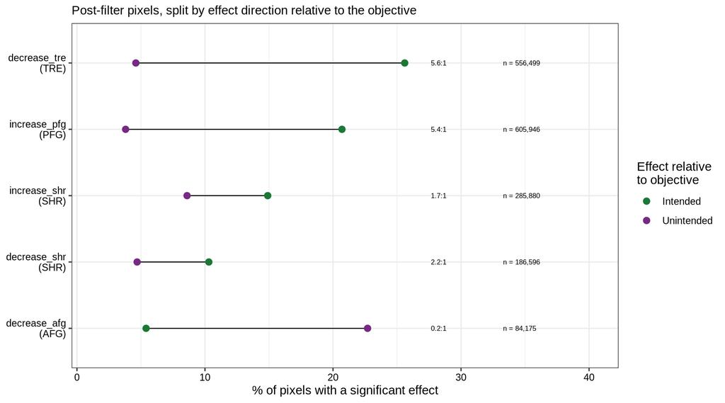

**Figure.** X axis: percentage of that objective by cover response combination’s post-filter pixels carrying a significant DART effect. Y axis: the objective and its cover response, ordered by the intended-effect rate so the figure reads top to bottom as a ranking. Colour: whether the effect was intended or unintended, resolved against each objective’s own goal through `get_intended_sign()`. The two points on a row are joined by a line whose direction, not only its length, carries meaning: a line running left-to-right from unintended to intended marks an objective whose intended effects dominate, and the one reversed line marks the objective where they do not. The right-hand text columns give the intended-to-unintended ratio and the pixel count for that row. Sample size is printed rather than mapped to point size, because the counts span an order of magnitude and point area would swamp the horizontal comparison the figure exists to make. No error bars: these are shares of a population of pixels, not estimates with a sampling distribution.

Significance rates by objective by cover response, with the overall rate split into intended and unintended shares of all pixels. The two shares sum to the overall rate up to rounding. Rows are ordered by the intended rate.

| Objective | Cover | Total Pixels | % Significant | % Significant (Intended) | % Significant (Unintended) |
| --- | --- | --- | --- | --- | --- |
| decrease_tre | TRE | 556499 | 30.2 | 25.6 | 4.6 |
| increase_pfg | PFG | 605946 | 24.6 | 20.7 | 3.8 |
| increase_shr | SHR | 285880 | 23.5 | 14.9 | 8.6 |
| decrease_shr | SHR | 186596 | 15.0 | 10.3 | 4.7 |
| decrease_afg | AFG | 84175 | 28.2 | 5.4 | 22.7 |

## 2. Treatment method was a major determinant of intended vegetation change

Treatment combination separates intended-effect rates more sharply than any other covariate examined descriptively, and it separates them in a direction that is consistent across most objectives: seeding paired with mechanical vegetation removal at one end, prescribed burning alone at the other.

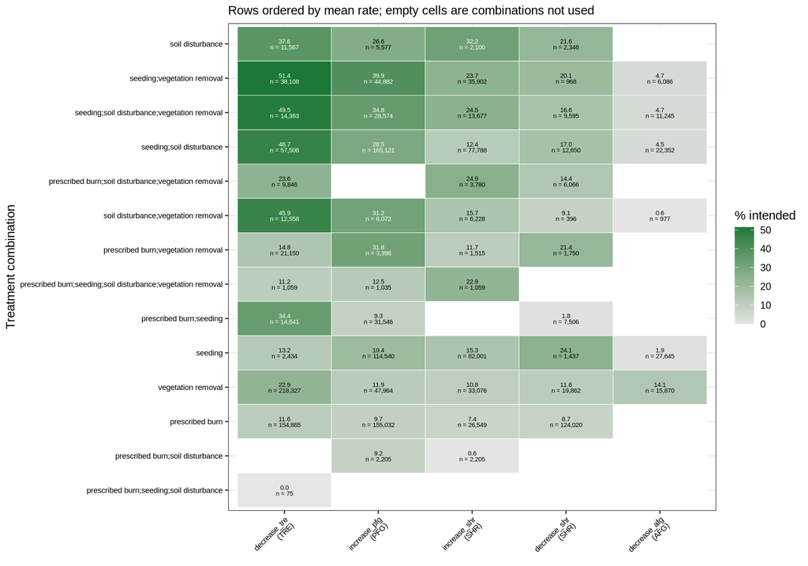

**Figure.** X axis: objective and cover response, ordered by overall intended-effect rate, so the columns run left to right in the ranking of Figure 1. Y axis: harmonized treatment combination, ordered by that treatment’s mean intended rate across the objectives it appears in rather than alphabetically, which is what makes the seeding and mechanical-removal combinations cluster toward the top and prescribed burn alone toward the bottom. Fill: the percentage of that cell’s pixels carrying a significant intended effect, pixel-weighted within the objective and summed over ecoregions. The rate and the pixel count are both printed in the cell; an empty cell is a combination not used for that objective, which is a different thing from a rate of zero and is drawn differently. No facets. The count is printed rather than encoded, because the counts span four orders of magnitude and the reason to show them is to let a reader discount a high rate resting on a thin cell.

Intended-effect rate by treatment combination within each objective, pixel-weighted and summed over ecoregions. Objectives are in the order of Figure 1 and treatments are ranked within each. A rule separates objectives.

| Objective | Cover | Treatment Combination | Total Pixels | # Significant (Intended) | % Significant (Intended) |
| --- | --- | --- | --- | --- | --- |
| decrease_tre | TRE | seeding;vegetation removal | 38108 | 19602 | 51.44 |
| decrease_tre | TRE | seeding;soil disturbance;vegetation removal | 14363 | 7117 | 49.55 |
| decrease_tre | TRE | seeding;soil disturbance | 57506 | 26841 | 46.68 |
| decrease_tre | TRE | soil disturbance;vegetation removal | 12558 | 5759 | 45.86 |
| decrease_tre | TRE | soil disturbance | 11567 | 4349 | 37.60 |
| decrease_tre | TRE | prescribed burn;seeding | 14641 | 5031 | 34.36 |
| decrease_tre | TRE | prescribed burn;soil disturbance;vegetation removal | 9846 | 2320 | 23.56 |
| decrease_tre | TRE | vegetation removal | 218327 | 49966 | 22.89 |
| decrease_tre | TRE | prescribed burn;vegetation removal | 21150 | 3131 | 14.80 |
| decrease_tre | TRE | seeding | 2434 | 322 | 13.23 |
| decrease_tre | TRE | prescribed burn | 154865 | 17942 | 11.59 |
| decrease_tre | TRE | prescribed burn;seeding;soil disturbance;vegetation removal | 1059 | 119 | 11.24 |
| decrease_tre | TRE | prescribed burn;seeding;soil disturbance | 75 | 0 | 0.00 |
| increase_pfg | PFG | seeding;vegetation removal | 44882 | 17928 | 39.94 |
| increase_pfg | PFG | seeding;soil disturbance;vegetation removal | 28574 | 9932 | 34.76 |
| increase_pfg | PFG | prescribed burn;vegetation removal | 3398 | 1079 | 31.75 |
| increase_pfg | PFG | soil disturbance;vegetation removal | 6072 | 1897 | 31.24 |
| increase_pfg | PFG | seeding;soil disturbance | 165121 | 47101 | 28.53 |
| increase_pfg | PFG | soil disturbance | 5577 | 1483 | 26.59 |
| increase_pfg | PFG | seeding | 114540 | 22278 | 19.45 |
| increase_pfg | PFG | prescribed burn;seeding;soil disturbance;vegetation removal | 1035 | 129 | 12.46 |
| increase_pfg | PFG | vegetation removal | 47964 | 5729 | 11.94 |
| increase_pfg | PFG | prescribed burn | 155032 | 15033 | 9.70 |
| increase_pfg | PFG | prescribed burn;seeding | 31546 | 2921 | 9.26 |
| increase_pfg | PFG | prescribed burn;soil disturbance | 2205 | 203 | 9.21 |
| increase_shr | SHR | soil disturbance | 2100 | 677 | 32.24 |
| increase_shr | SHR | prescribed burn;soil disturbance;vegetation removal | 3780 | 940 | 24.87 |
| increase_shr | SHR | seeding;soil disturbance;vegetation removal | 13677 | 3349 | 24.49 |
| increase_shr | SHR | seeding;vegetation removal | 35902 | 8507 | 23.70 |
| increase_shr | SHR | prescribed burn;seeding;soil disturbance;vegetation removal | 1059 | 242 | 22.85 |
| increase_shr | SHR | soil disturbance;vegetation removal | 6228 | 976 | 15.67 |
| increase_shr | SHR | seeding | 82001 | 12589 | 15.35 |
| increase_shr | SHR | seeding;soil disturbance | 77788 | 9620 | 12.37 |
| increase_shr | SHR | prescribed burn;vegetation removal | 1515 | 177 | 11.68 |
| increase_shr | SHR | vegetation removal | 33076 | 3584 | 10.84 |
| increase_shr | SHR | prescribed burn | 26549 | 1960 | 7.38 |
| increase_shr | SHR | prescribed burn;soil disturbance | 2205 | 14 | 0.63 |
| decrease_shr | SHR | seeding | 1437 | 347 | 24.15 |
| decrease_shr | SHR | soil disturbance | 2346 | 507 | 21.61 |
| decrease_shr | SHR | prescribed burn;vegetation removal | 1750 | 375 | 21.43 |
| decrease_shr | SHR | seeding;vegetation removal | 968 | 195 | 20.14 |
| decrease_shr | SHR | seeding;soil disturbance | 12650 | 2153 | 17.02 |
| decrease_shr | SHR | seeding;soil disturbance;vegetation removal | 9595 | 1591 | 16.58 |
| decrease_shr | SHR | prescribed burn;soil disturbance;vegetation removal | 6066 | 875 | 14.42 |
| decrease_shr | SHR | vegetation removal | 19862 | 2305 | 11.61 |
| decrease_shr | SHR | soil disturbance;vegetation removal | 396 | 36 | 9.09 |
| decrease_shr | SHR | prescribed burn | 124020 | 10732 | 8.65 |
| decrease_shr | SHR | prescribed burn;seeding | 7506 | 131 | 1.75 |
| decrease_afg | AFG | vegetation removal | 15870 | 2232 | 14.06 |
| decrease_afg | AFG | seeding;vegetation removal | 6086 | 288 | 4.73 |
| decrease_afg | AFG | seeding;soil disturbance;vegetation removal | 11245 | 524 | 4.66 |
| decrease_afg | AFG | seeding;soil disturbance | 22352 | 997 | 4.46 |
| decrease_afg | AFG | seeding | 27645 | 518 | 1.87 |
| decrease_afg | AFG | soil disturbance;vegetation removal | 977 | 6 | 0.61 |

## 3. Intended effects weakened with time since treatment

This is the most general result in the analysis: it holds in every objective, on both the overall significance rate and the intended rate, and it is the one finding that does not depend on which objective or treatment is being examined.

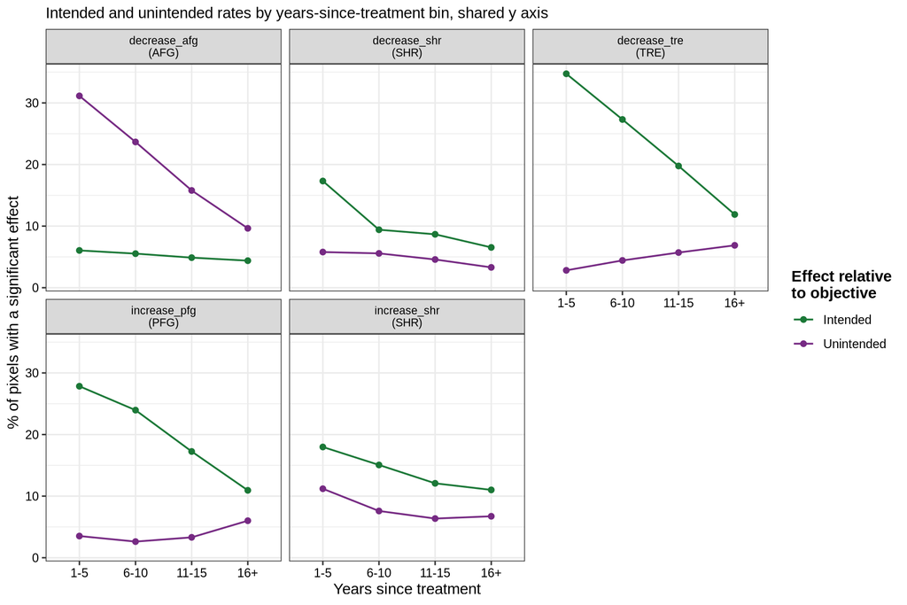

**Figure.** X axis: years-since-treatment bin, in order. Y axis: percentage of that bin’s pixels carrying a significant effect, on a scale shared across all panels. Colour: intended or unintended, resolved per panel against that objective’s own goal, so a `decrease_*` panel’s intended line is its negative rate and an `increase_*` panel’s is its positive rate. Facets: objective by cover response. The shared y axis is the point of the figure - the claim is that every panel declines and that in two of them the unintended line rises toward the intended one, and free scales would turn five related panels into five unrelated ones. Bin sample sizes are in the table below rather than on the figure.

Significance rates by years-since-treatment bin, with the overall rate split into intended and unintended shares. Objectives are in the order of Figure 1. A rule separates objectives.

| Objective | Cover | Years Since Treatment | Total Pixels | % Significant | % Significant (Intended) | % Significant (Unintended) |
| --- | --- | --- | --- | --- | --- | --- |
| decrease_tre | TRE | 1-5 | 189705 | 37.55 | 34.73 | 2.82 |
| decrease_tre | TRE | 6-10 | 156175 | 31.74 | 27.31 | 4.43 |
| decrease_tre | TRE | 11-15 | 113531 | 25.46 | 19.76 | 5.71 |
| decrease_tre | TRE | 16+ | 97088 | 18.76 | 11.89 | 6.88 |
| increase_pfg | PFG | 1-5 | 183780 | 31.35 | 27.84 | 3.52 |
| increase_pfg | PFG | 6-10 | 157858 | 26.57 | 23.96 | 2.62 |
| increase_pfg | PFG | 11-15 | 124093 | 20.55 | 17.25 | 3.31 |
| increase_pfg | PFG | 16+ | 140215 | 16.95 | 10.94 | 6.01 |
| increase_shr | SHR | 1-5 | 105532 | 29.18 | 17.98 | 11.20 |
| increase_shr | SHR | 6-10 | 80672 | 22.64 | 15.06 | 7.59 |
| increase_shr | SHR | 11-15 | 50252 | 18.44 | 12.08 | 6.36 |
| increase_shr | SHR | 16+ | 49424 | 17.74 | 11.01 | 6.73 |
| decrease_shr | SHR | 1-5 | 45846 | 23.11 | 17.32 | 5.79 |
| decrease_shr | SHR | 6-10 | 43563 | 14.98 | 9.41 | 5.57 |
| decrease_shr | SHR | 11-15 | 40274 | 13.25 | 8.67 | 4.58 |
| decrease_shr | SHR | 16+ | 56913 | 9.83 | 6.54 | 3.30 |
| decrease_afg | AFG | 1-5 | 30549 | 37.19 | 6.05 | 31.14 |
| decrease_afg | AFG | 6-10 | 24418 | 29.20 | 5.53 | 23.66 |
| decrease_afg | AFG | 11-15 | 16895 | 20.66 | 4.88 | 15.79 |
| decrease_afg | AFG | 16+ | 12313 | 14.03 | 4.39 | 9.64 |

Peak mean effect over significant pixels, by objective and direction. Shown to document why the year-bin analysis above carries the temporal argument instead: a starred row rests on fewer than 50 significant pixels, and a censored row peaks on the last observed year, so its peak may simply be where the record stops. SE is blank where the peak rests on a single pixel.

Peak Year

Peak Mean Effect

SE

# Significant Pixels

Last Year

Censored

< 50 px

decrease_afg_AFG

negative

18

-43.26

1.79

132

26

FALSE

decrease_afg_AFG

positive

25

28.78

3.53

10

26

FALSE

decrease_shr_SHR

negative

1

-21.38

0.26

2455

32

FALSE

decrease_shr_SHR

positive

27

14.20

NA

1

32

FALSE

decrease_tre_TRE

negative

29

-26.64

1.02

100

33

FALSE

decrease_tre_TRE

positive

31

14.24

1.26

27

33

FALSE

increase_pfg_PFG

negative

21

-10.59

0.15

733

33

FALSE

increase_pfg_PFG

positive

33

23.43

2.36

17

33

TRUE

increase_shr_SHR

negative

2

-11.87

0.11

2907

30

FALSE

increase_shr_SHR

positive

20

14.01

0.34

378

30

FALSE

## 4. Treatments produced broader community responses, and outcomes varied in space

### Non-target cover responses

Treating one functional group did not leave the others alone. In pixels where a given objective was being pursued, the non-target cover responses carried significance rates comparable to the target response.

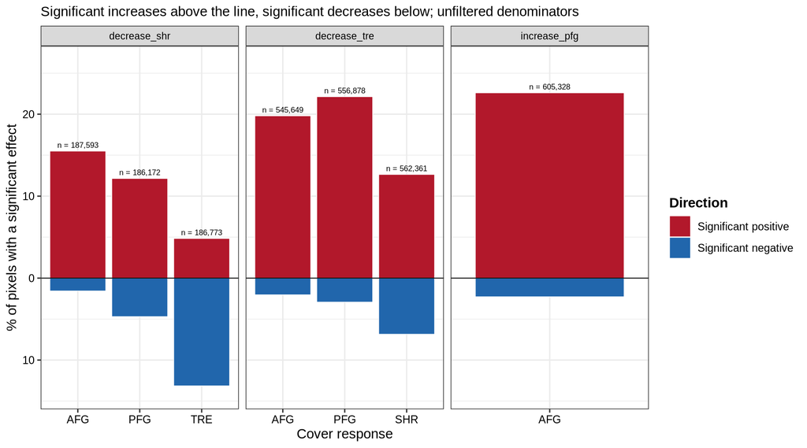

**Figure.** X axis: the non-target cover response, which differs by panel because each objective has its own set of responses worth asking about. Y axis: percentage of that response’s pixels carrying a significant effect, with significant increases plotted above the zero line and significant decreases below it, and the axis labelled in absolute values; the scale is shared across panels. Fill: raw sign of the effect, in the same red and blue every raw-sign figure in this project uses. Facets: the objective being pursued in those pixels. Raw sign rather than intent is forced here rather than chosen - a non-target response has no assigned objective against which a sign could be called intended. The sample sizes are the **unfiltered** post-treatment pixel counts for that objective, which is also why these percentages must not be compared numerically with the filtered intended-effect rates in Figure 1.

Non-target cover responses in treated pixels, by the objective being pursued. Denominators are the full post-treatment data for that objective, not the post-filter analysis set, so these rates are not comparable with the compiled tables above.

| Objective Pursued | Cover Response | Total Pixels | % Significant | % Significant Positive | % Significant Negative |
| --- | --- | --- | --- | --- | --- |
| decrease_tre | AFG | 545649 | 21.82 | 19.79 | 2.03 |
| decrease_tre | PFG | 556878 | 25.04 | 22.13 | 2.92 |
| decrease_tre | SHR | 562361 | 19.49 | 12.64 | 6.84 |
| increase_pfg | AFG | 605328 | 24.87 | 22.60 | 2.27 |
| decrease_shr | AFG | 187593 | 17.05 | 15.49 | 1.56 |
| decrease_shr | PFG | 186172 | 16.84 | 12.15 | 4.69 |
| decrease_shr | TRE | 186773 | 17.97 | 4.83 | 13.14 |

### Ecoregional variation

For each objective: the spread of intended-effect rates across Level IV ecoregions, the ecoregion with the highest rate alongside its sample size and its rank among that objective’s ecoregions by pixel count, and the largest ecoregion for comparison. The pairing is the point - the extreme cell and the well-sampled cell are rarely the same one.

| Objective | # Ecoregions | Range of Rates | Highest-Rate Ecoregion | % Intended | Pixels | % of Objective | Rank by Size | Largest Ecoregion | % Intended | Pixels |
| --- | --- | --- | --- | --- | --- | --- | --- | --- | --- | --- |
| decrease_afg | 14 | 25.49 | Uinta Basin Floor | 25.79 | 1008 | 1.20 | 11 | Sagebrush Basins and Slopes | 8.87 | 26304 |
| decrease_shr | 8 | 28.38 | Sagebrush Basins and Slopes | 29.45 | 12993 | 6.96 | 3 | Semiarid Benchlands and Canyonlands | 8.79 | 132266 |
| decrease_tre | 15 | 92.86 | High Elevation Forests and Shrublands | 100.00 | 16 | 0.00 | 15 | Semiarid Benchlands and Canyonlands | 19.28 | 265245 |
| increase_pfg | 22 | 84.86 | High Elevation Carbonate Mountains | 87.13 | 1974 | 0.33 | 17 | Semiarid Benchlands and Canyonlands | 17.59 | 229443 |
| increase_shr | 19 | 76.71 | High Elevation Carbonate Mountains | 76.80 | 1974 | 0.69 | 14 | Semiarid Benchlands and Canyonlands | 14.57 | 77752 |

## Caveats carried by every number above

The share of each objective’s analysis pixels that carry no other management objective. Only decrease_tre has a substantial uniquely assigned component.

| Objective | Cover | Pixels With No Other Objective | % With No Other Objective |
| --- | --- | --- | --- |
| decrease_tre | TRE | 212111 | 38.12 |
| increase_pfg | PFG | 114791 | 18.94 |
| decrease_afg | AFG | 4781 | 5.68 |
| decrease_shr | SHR | 8560 | 4.59 |
| increase_shr | SHR | 2525 | 0.88 |

- **Objective groupings are not a partition.** A pixel counts toward an objective if it fell in any part of that objective, so multi-objective treatments appear in several groupings and parts of the dataset are counted more than once. The table above makes that quantitative: outside `decrease_tre`, between 0.88% and 18.94% of an objective’s pixels carry no second objective. The five analyses are five ways of interrogating overlapping restoration landscapes, not five independent experiments.
- **An objective and response pairing is only included when the response cover type matches the objective’s target cover**, with bare ground the sole exception, shown against all objectives. Mechanically that exception is inert in the current data, which carries no bare-ground rows, so no bare-ground result is reported anywhere here.
- **Pixels are not independent replicates.** They are nested in treatment polygons and the polygon is the unit a manager acts on, so a pixel-weighted rate gives a large polygon more influence than a small one. Every rate above is pixel-weighted. The per-polygon tables in `2_make_DART_results.Rmd` carry the other framing, and the two have not been reconciled.
- **Nothing above adjusts for anything.** These are marginal rates: the treatment comparison does not hold ecoregion or climate constant, the time comparison does not hold treatment constant, and no interval around any of them accounts for the nesting. Claims of the form “treatment A outperformed treatment B under otherwise comparable conditions” are not supported by this document.

## What this document does not yet support

KY’s `analysis_modification_suggestions_08102026` proposes nine further analyses. Recorded here so that the gap between what is shown above and what the manuscript might claim is explicit, and so that the list does not have to be re-derived.

- **Not addressed at all.** Formal treatment-component synergy tests; the objective-overlap sensitivity analysis re-running the headline results on single-objective and bundled subsets; a persistence analysis estimating time to 50% loss of the initial effect; climate as a moderator, separating long-term site aridity from post-treatment drought; partial-pooling estimates replacing the raw ecoregion rankings; a multivariate treatment of the non-target responses as response syndromes; and the robustness set (a common treatment by ecoregion threshold across objectives, and 90% against 95% uncertainty thresholds).
- **Partly addressed elsewhere.** The hierarchical model of the continuous effect, with treatment, time, aridity, SPEI and ecoregion and a polygon random effect, has been fitted once and is reported in `3_report_lme4_models.Rmd`. It is a linear specification in time rather than the spline or piecewise form the suggestions call for, it does not carry the proposed interactions, and it is being revised, so nothing from it is quoted here or carried into the manuscript.
- **A standing ambiguity the list makes sharper.** The pixel-weighted landscape rate and the polygon-weighted project rate answer different management questions - what fraction of treated land responded, against what the average treatment project achieved - and this document reports only the first. Which of the two the manuscript should lead with is a decision, not a calculation.